# Exploratory Data Analysis on Heart Disease UCI

# by(mostafa mohamed mostafa)

# review

# the dataset contain 14 feature and 100000 of record of patients

# Variables or features explanations:

1-age (Age in years)

2=sex : (1 = male, 0 = female)

3-cp (Chest Pain Type): ( 0: asymptomatic, 1: atypical angina, 2: non-anginal pain, 3: typical angina)

4-trestbps (Resting Blood Pressure in mm/hg )

5-chol (Serum Cholesterol in mg/dl)

6-fps (Fasting Blood Sugar > 120 mg/dl): (0 = no, 1 = yes)

7-restecg (Resting ECG): (0: showing probable or definite left ventricular hypertrophy by Estes’ criteria, 1: normal, 2: having -ST-T wave abnormality]

8-thalach (maximum heart rate achieved)

9-exang (Exercise Induced Angina): (1 = yes, 0 = no)

10-oldpeak (ST depression induced by exercise relative to rest)

11-slope (the slope of the peak exercise ST segment): (0: downsloping; 1: flat; 2: upsloping)

12-ca (number of major vessels (0–3)

13-thal : (1 = normal, 2 = fixed defect, 3 = reversible defect)

14-target: (0 = disease, 1 = no disease)

# display data

|  | age | cp | trestbps | chol | fbs | restecg | thalach | exang | oldpeak | slope | ca | thal | target | sex |
| --- | --- | --- | --- | --- | --- | --- | --- | --- | --- | --- | --- | --- | --- | --- |
| 0 | 60 | 3 | 150 | 240 | 0 | 1 | 171 | 0 | 0.90000 | 2 | 0 | 2 | 1 | 0 |
| 1 | 65 | 0 | 135 | 254 | 0 | 0 | 127 | 0 | 2.80000 | 1 | 1 | 3 | 0 | 1 |
| 2 | 58 | 2 | 105 | 240 | 0 | 0 | 154 | 1 | 0.60000 | 1 | 0 | 3 | 1 | 1 |
| 3 | 49 | 0 | 130 | 269 | 0 | 1 | 162 | 0 | 0.00000 | 1 | 0 | 2 | 1 | 0 |
| 4 | 45 | 1 | 112 | 160 | 0 | 1 | 138 | 0 | 0.00000 | 1 | 0 | 2 | 1 | 0 |
| ... | ... | ... | ... | ... | ... | ... | ... | ... | ... | ... | ... | ... | ... | ... |
| 99995 | 65 | 1 | 145 | 241 | 0 | 1 | 152 | 0 | 1.57929 | 1 | 0 | 2 | 0 | 0 |
| 99996 | 59 | 2 | 126 | 218 | 1 | 1 | 134 | 0 | 2.20000 | 1 | 1 | 1 | 0 | 1 |
| 99997 | 42 | 2 | 120 | 240 | 1 | 1 | 194 | 0 | 0.80000 | 0 | 0 | 3 | 1 | 1 |
| 99998 | 43 | 0 | 132 | 247 | 1 | 0 | 143 | 1 | 0.10000 | 1 | 4 | 3 | 0 | 1 |
| 99999 | 69 | 3 | 160 | 234 | 1 | 0 | 131 | 0 | 0.10000 | 1 | 1 | 2 | 1 | 1 |

100000 rows × 14 columns

# data inforantion

```
<class 'pandas.core.frame.DataFrame'>
RangeIndex: 100000 entries, 0 to 99999
Data columns (total 14 columns):
 #   Column    Non-Null Count   Dtype
---  ------    --------------   -----
 0   age       100000 non-null  int64
 1   cp        100000 non-null  int64
 2   trestbps  100000 non-null  int64
 3   chol      100000 non-null  int64
 4   fbs       100000 non-null  int64
 5   restecg   100000 non-null  int64
 6   thalach   100000 non-null  int64
 7   exang     100000 non-null  int64
 8   oldpeak   100000 non-null  float64
 9   slope     100000 non-null  int64
 10  ca        100000 non-null  int64
 11  thal      100000 non-null  int64
 12  target    100000 non-null  int64
 13  sex       100000 non-null  int64
dtypes: float64(1), int64(13)
memory usage: 10.7 MB
```

# som statistic for data

|  | age | cp | trestbps | chol | fbs | restecg | thalach | exang | oldpeak | slope | ca | thal | target | sex |
| --- | --- | --- | --- | --- | --- | --- | --- | --- | --- | --- | --- | --- | --- | --- |
| count | 100000.000000 | 100000.000000 | 100000.00000 | 100000.000000 | 100000.000000 | 100000.000000 | 100000.000000 | 100000.000000 | 100000.000000 | 100000.000000 | 100000.000000 | 100000.000000 | 100000.000000 | 100000.000000 |
| mean | 54.766530 | 0.924030 | 132.07646 | 250.142150 | 0.122260 | 0.507420 | 149.613820 | 0.273370 | 1.024055 | 1.354830 | 0.653530 | 2.243000 | 0.564320 | 0.499160 |
| std | 9.067179 | 0.983528 | 17.73196 | 55.987246 | 0.327587 | 0.527435 | 21.927514 | 0.445691 | 1.140888 | 0.607527 | 0.974135 | 0.577143 | 0.495848 | 0.500002 |
| min | 29.000000 | 0.000000 | 94.00000 | 126.000000 | 0.000000 | 0.000000 | 71.000000 | 0.000000 | 0.000000 | 0.000000 | 0.000000 | 0.000000 | 0.000000 | 0.000000 |
| 25% | 48.000000 | 0.000000 | 120.00000 | 211.000000 | 0.000000 | 0.000000 | 136.000000 | 0.000000 | 0.000000 | 1.000000 | 0.000000 | 2.000000 | 0.000000 | 0.000000 |
| 50% | 56.000000 | 1.000000 | 130.00000 | 243.000000 | 0.000000 | 0.000000 | 153.000000 | 0.000000 | 0.731685 | 1.000000 | 0.000000 | 2.000000 | 1.000000 | 0.000000 |
| 75% | 62.000000 | 2.000000 | 140.00000 | 282.000000 | 0.000000 | 1.000000 | 165.000000 | 1.000000 | 1.600000 | 2.000000 | 1.000000 | 3.000000 | 1.000000 | 1.000000 |
| max | 77.000000 | 3.000000 | 200.00000 | 564.000000 | 1.000000 | 2.000000 | 202.000000 | 1.000000 | 6.200000 | 2.000000 | 4.000000 | 3.000000 | 1.000000 | 1.000000 |

```
age         0
cp          0
trestbps    0
chol        0
fbs         0
restecg     0
thalach     0
exang       0
oldpeak     0
slope       0
ca          0
thal        0
target      0
sex         0
dtype: int64
```

```
Index(['age', 'cp', 'trestbps', 'chol', 'fbs', 'restecg', 'thalach', 'exang',
       'oldpeak', 'slope', 'ca', 'thal', 'target', 'sex'],
      dtype='object')
```

# correlation between feature

|  | age | cp | trestbps | chol | fbs | restecg | thalach | exang | oldpeak | slope | ca | thal | target | sex |
| --- | --- | --- | --- | --- | --- | --- | --- | --- | --- | --- | --- | --- | --- | --- |
| age | 1.000000 | -0.066047 | 0.262922 | 0.229583 | 0.101144 | -0.109502 | -0.404677 | 0.055780 | 0.200990 | -0.136180 | 0.273430 | 0.054870 | -0.215480 | -0.099095 |
| cp | -0.066047 | 1.000000 | -0.011169 | -0.064896 | 0.064708 | 0.052760 | 0.280744 | -0.370534 | -0.191752 | 0.153781 | -0.167973 | -0.154271 | 0.422230 | -0.011772 |
| trestbps | 0.262922 | -0.011169 | 1.000000 | 0.145097 | 0.181214 | -0.120009 | -0.059447 | 0.130015 | 0.249951 | -0.171351 | 0.134953 | 0.061935 | -0.209706 | -0.066482 |
| chol | 0.229583 | -0.064896 | 0.145097 | 1.000000 | 0.035230 | -0.197609 | 0.004614 | 0.043797 | 0.078082 | 0.017984 | 0.056848 | 0.094101 | -0.108698 | -0.195680 |
| fbs | 0.101144 | 0.064708 | 0.181214 | 0.035230 | 1.000000 | -0.106246 | -0.031100 | 0.097792 | 0.045268 | -0.042567 | 0.178306 | -0.008300 | -0.088676 | 0.096419 |
| restecg | -0.109502 | 0.052760 | -0.120009 | -0.197609 | -0.106246 | 1.000000 | 0.022777 | -0.025709 | -0.055046 | 0.102058 | -0.077686 | -0.005660 | 0.118546 | 0.007001 |
| thalach | -0.404677 | 0.280744 | -0.059447 | 0.004614 | -0.031100 | 0.022777 | 1.000000 | -0.334711 | -0.326078 | 0.381051 | -0.204070 | -0.086035 | 0.395401 | -0.056780 |
| exang | 0.055780 | -0.370534 | 0.130015 | 0.043797 | 0.097792 | -0.025709 | -0.334711 | 1.000000 | 0.296729 | -0.224399 | 0.130032 | 0.225993 | -0.436340 | 0.235477 |
| oldpeak | 0.200990 | -0.191752 | 0.249951 | 0.078082 | 0.045268 | -0.055046 | -0.326078 | 0.296729 | 1.000000 | -0.559528 | 0.276547 | 0.224578 | -0.466800 | 0.102222 |
| slope | -0.136180 | 0.153781 | -0.171351 | 0.017984 | -0.042567 | 0.102058 | 0.381051 | -0.224399 | -0.559528 | 1.000000 | -0.078779 | -0.080096 | 0.354578 | 0.033589 |
| ca | 0.273430 | -0.167973 | 0.134953 | 0.056848 | 0.178306 | -0.077686 | -0.204070 | 0.130032 | 0.276547 | -0.078779 | 1.000000 | 0.190894 | -0.399054 | 0.182243 |
| thal | 0.054870 | -0.154271 | 0.061935 | 0.094101 | -0.008300 | -0.005660 | -0.086035 | 0.225993 | 0.224578 | -0.080096 | 0.190894 | 1.000000 | -0.342415 | 0.277625 |
| target | -0.215480 | 0.422230 | -0.209706 | -0.108698 | -0.088676 | 0.118546 | 0.395401 | -0.436340 | -0.466800 | 0.354578 | -0.399054 | -0.342415 | 1.000000 | -0.290195 |
| sex | -0.099095 | -0.011772 | -0.066482 | -0.195680 | 0.096419 | 0.007001 | -0.056780 | 0.235477 | 0.102222 | 0.033589 | 0.182243 | 0.277625 | -0.290195 | 1.000000 |

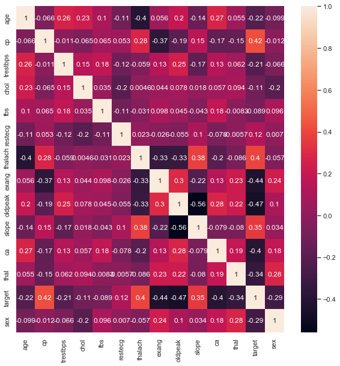

```
Index(['age', 'cp', 'trestbps', 'chol', 'fbs', 'restecg', 'thalach', 'exang',
       'oldpeak', 'slope', 'ca', 'thal', 'target', 'sex'],
      dtype='object')
```

# display and drop outliers

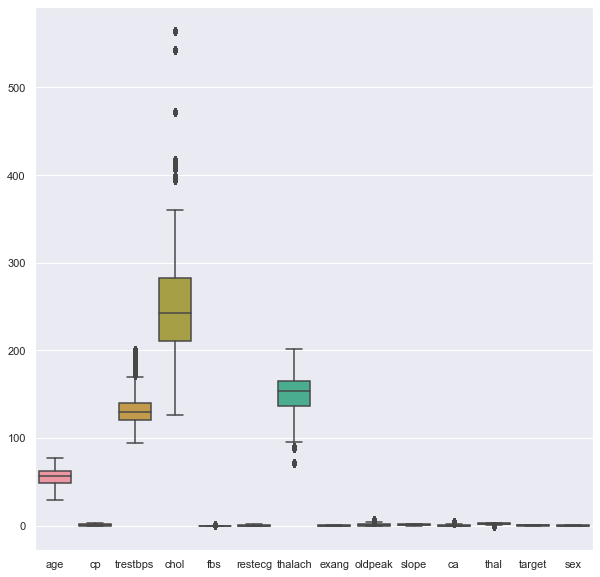

# statistic of data after drop outliers

|  | age | cp | trestbps | chol | fbs | restecg | thalach | exang | oldpeak | slope | ca | thal | target | sex |
| --- | --- | --- | --- | --- | --- | --- | --- | --- | --- | --- | --- | --- | --- | --- |
| count | 85958.000000 | 85958.000000 | 85958.000000 | 85958.000000 | 85958.000000 | 85958.000000 | 85958.000000 | 85958.000000 | 85958.000000 | 85958.000000 | 85958.000000 | 85958.000000 | 85958.000000 | 85958.000000 |
| mean | 54.153994 | 0.969055 | 129.453687 | 244.628412 | 0.098944 | 0.512588 | 151.390412 | 0.250960 | 0.911692 | 1.395007 | 0.457328 | 2.233672 | 0.607913 | 0.496301 |
| std | 9.133275 | 0.986216 | 14.927943 | 45.911255 | 0.298588 | 0.512781 | 21.077897 | 0.433568 | 0.988835 | 0.596650 | 0.699302 | 0.524252 | 0.488219 | 0.499989 |
| min | 29.000000 | 0.000000 | 94.000000 | 126.000000 | 0.000000 | 0.000000 | 95.000000 | 0.000000 | 0.000000 | 0.000000 | 0.000000 | 1.000000 | 0.000000 | 0.000000 |
| 25% | 47.000000 | 0.000000 | 120.000000 | 209.000000 | 0.000000 | 0.000000 | 139.000000 | 0.000000 | 0.000000 | 1.000000 | 0.000000 | 2.000000 | 0.000000 | 0.000000 |
| 50% | 55.000000 | 1.000000 | 130.000000 | 241.000000 | 0.000000 | 1.000000 | 155.000000 | 0.000000 | 0.600000 | 1.000000 | 0.000000 | 2.000000 | 1.000000 | 0.000000 |
| 75% | 61.000000 | 2.000000 | 140.000000 | 275.000000 | 0.000000 | 1.000000 | 168.000000 | 1.000000 | 1.414977 | 2.000000 | 1.000000 | 3.000000 | 1.000000 | 1.000000 |
| max | 76.000000 | 3.000000 | 170.000000 | 360.000000 | 1.000000 | 2.000000 | 202.000000 | 1.000000 | 4.000000 | 2.000000 | 2.000000 | 3.000000 | 1.000000 | 1.000000 |

# count of target for every class

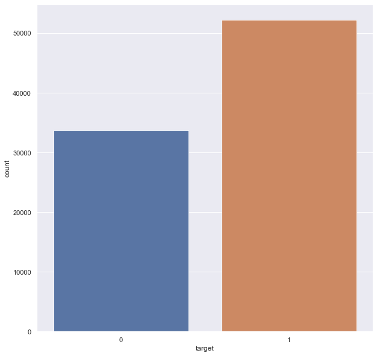

# count of sex for every class

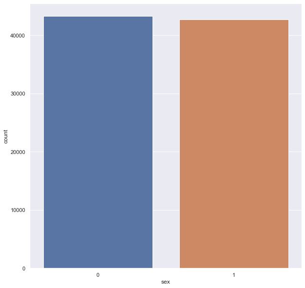

# distribution sex according to target

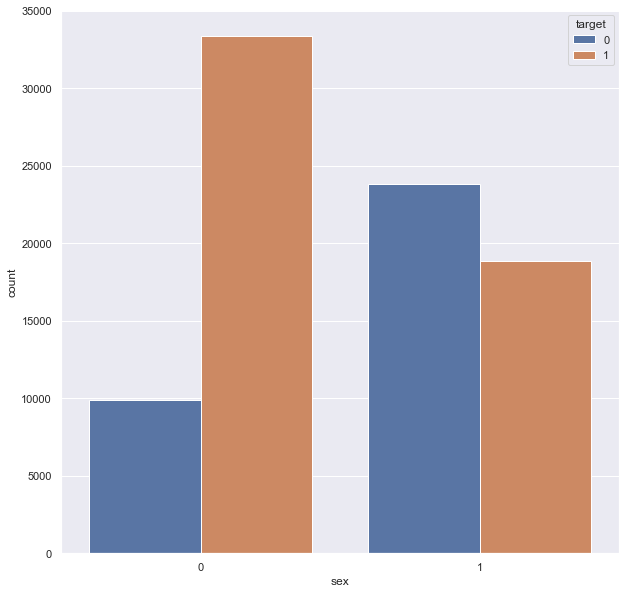

# count of chest_pain for every class

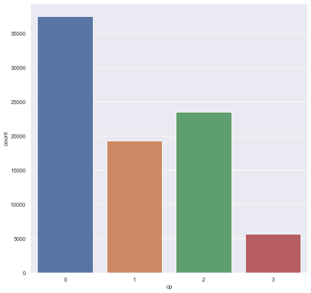

# distribution chest_pain according to target

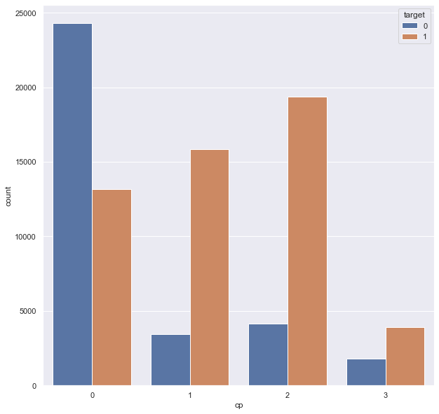

# distribution age according to target

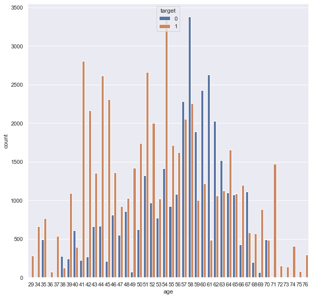

# distribution targer according to age and sex

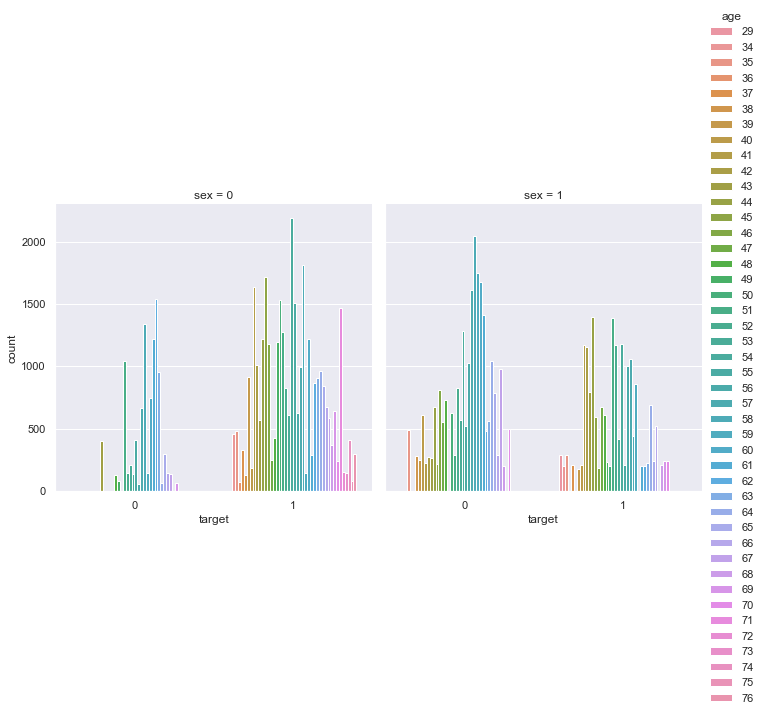

# distribution Fasting Blood Sugar according to target

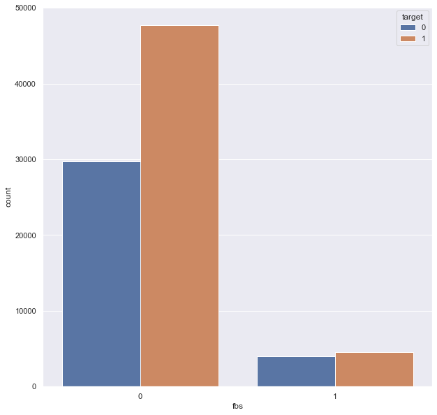

# observation

# Males are more susceptible to heart_disease than females

# number of disease less than no disease

# chest pain with type asymptomatic case the higher rate of heat disease

# major people with age between 50 and 63 with heart diseas

# fbs might not be a strong feature differentiating between heart disease an non-disease patient